# Como criar uma instância com Rstudio instalado na Amazon EC2

# Como ter um Rstudio numa máquina com muita memória na Amazom

## 1. Criar uma conta na Amazon

Entre no site da (Amazon Aws)[http://aws.amazon.com/pt/] e crie uma conta.

## 2. Fazer login e ir para o AWS Management Console

[figure not shown]

Clique em EC2 (Elastic Compute Cloud), este é o serviço que usamos quando queremos criar um computador na nuvem.

## 3. No Dashboard do EC2 clique em Launch Instance

[figure not shown]

## 4. Clique em Community AMI's e procure por RStudio

[figure not shown]

Selecione a primeira, que é a mias atualizada, e clique em Select

## 5. Selecione o tamanho da sua instância

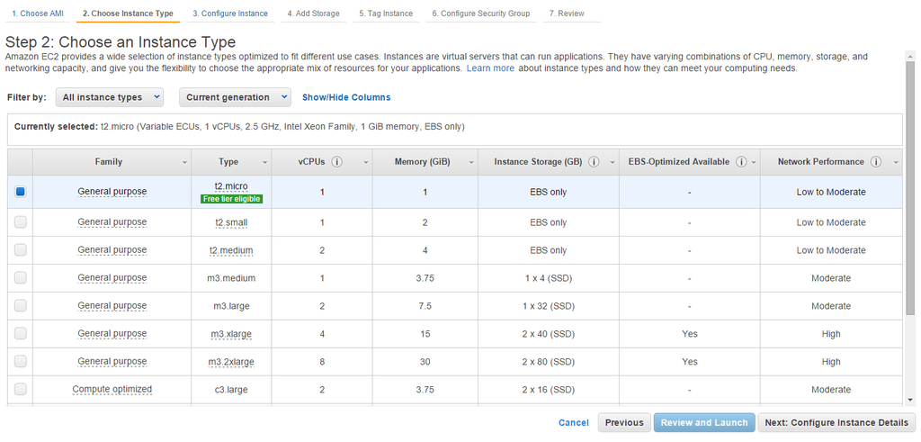

Clique em Next: Configure Instance Details no canto direito inferior para continuar.

## 6. Aqui são opções mais avançadas...

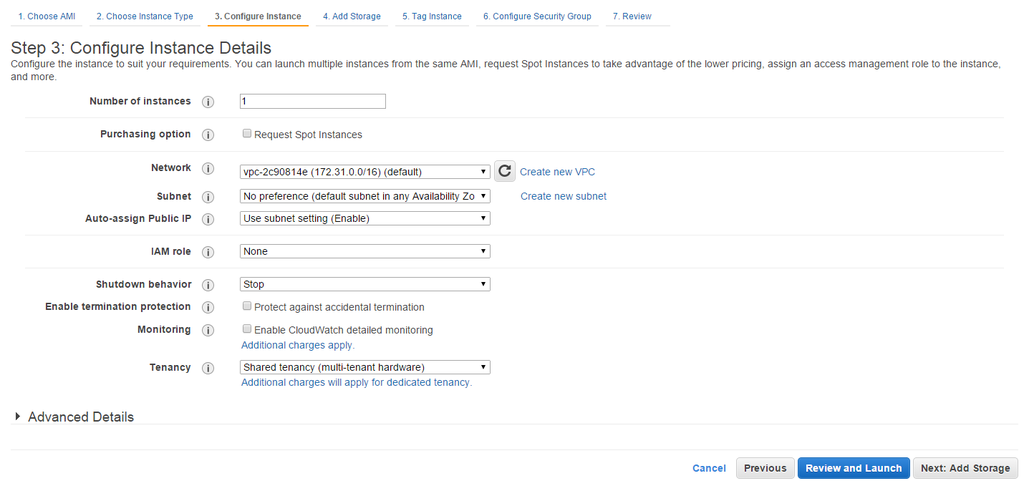

Apenas clique em Next: Add Storage para continuar.

## 7. Coloque a quantidade de espaço de HD que você precisa na sua instância

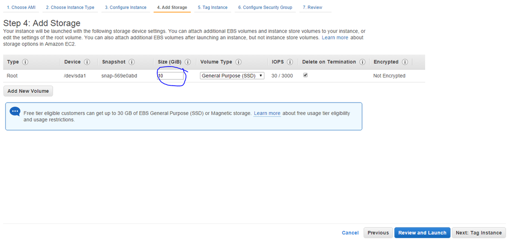

Esse é o tamanho do disco rígido da sua máquina, ele precisa comportar a sua base e todos os arquivos que você precisar salvar.

Clique em Next: Tag Instance

## 8. Aqui você só precisa dar um nome para a sua instância

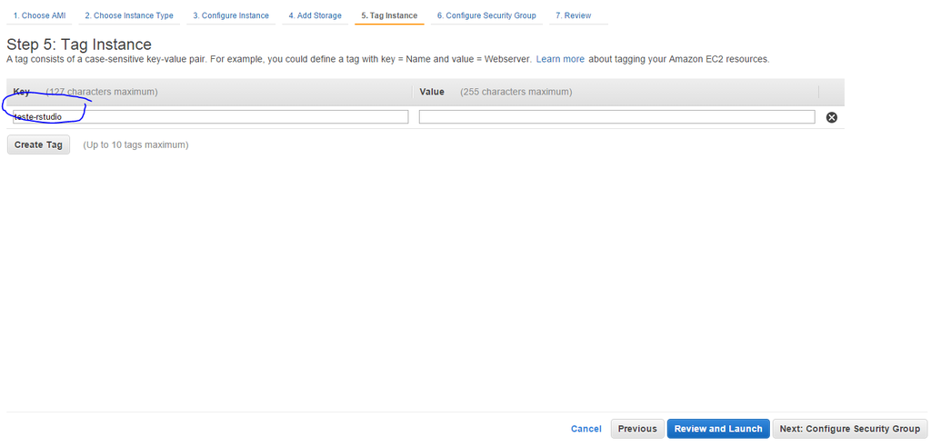

Clique em Next: Configure Security Group

## 9. Configurações de segurança da instância

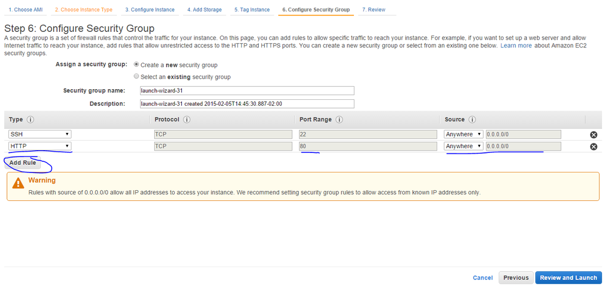

Clique em Add Rule, em seguida "http". Assim você está liberando o acesso à sua instância pela porta Http. É recomendável trocar a opção "Anywhere" por "My Ip".

Clique em Review and Launch.

## 10. Verifique suas configurações e clique em Launch

[figure not shown]

## 11. A página a seguir aparecerá:

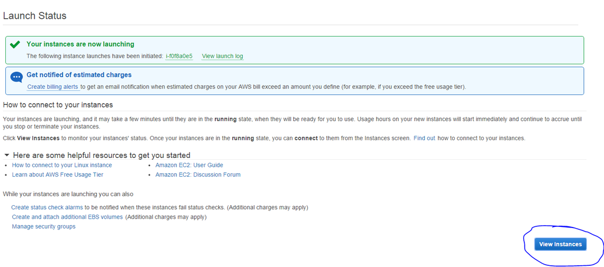

Clique em View Instances

## 12. Acessar a sua instância

Quando o estado da sua instância for "running" ela estará pronta, e terá um Public DNS.

[figure not shown]

Copie e cole o Public DNS no seu navegador, como se fosse um site que você deseja acessar.

## 13. Se tudo estiver correto...

[figure not shown]

O Rstudio aparecerá. O login é rstudio e a senha também.

## 14. Para parar de pagar pela instância:

Selecione a instância, clique em actions, Instance State, Terminate. Isso desligará o servidor e você perderá tudo que tem nele. Se você clicar em stop, você não perderá o que está armazenado na instância e poderá ligá-la a qualquer momento. No entanto estará pagando pelo armazenamento.

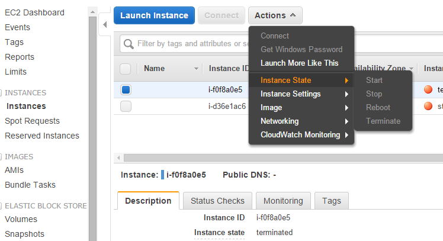